# Лабораторная работа №1

Студент гр. РИ-440005, Водяный Михаил

**Цель работы:** Проверка следующих навыков: Манипулирование объектами данных; использование встроенных функций; построение простейших графиков; простейшие статистические концепции.

### Задание 1

1. Сгенерируйте 200 случайных значений из стандартного экспоненциального распределения и сохраните в вектор exp.1. Найдите среднее и стандартное отклонение из данных этого вектора.

Формула экспоненциального распределения: $F(x) = 1 - e^{-\lambda*x}$

```r
exp.1 <- rexp(n = 200)
mean(exp.1)
```

```
## [1] 1.141352
```

```r
sd(exp.1)
```

```
## [1] 1.192113
```

2. Повторите, использовав следующие значения параметра λ: 0.1, 0.5, 5, 10, и сохраните результаты в векторы: exp.0.1, exp.0.5, exp.5, exp.10.

```r
exp.0.1 <- rexp(n = 200, rate = 0.1)
exp.0.5 <- rexp(n = 200, rate = 0.5)
exp.5 <- rexp(n = 200, rate = 5)
exp.10 <- rexp(n = 200, rate = 10)
```

3. Используйте функцию hist() для построения гистограммы полученного ранее стандартного распределения.

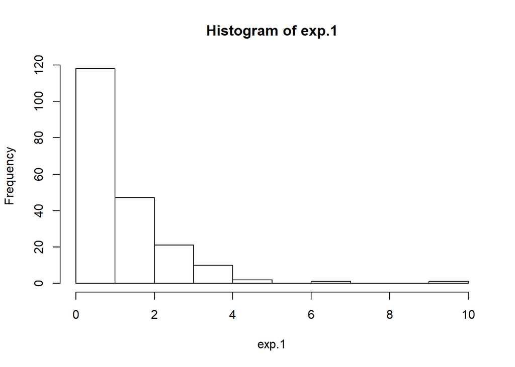

4. Используйте функцию plot() с тем же самым вектором для построения графика значений в порядке следования.

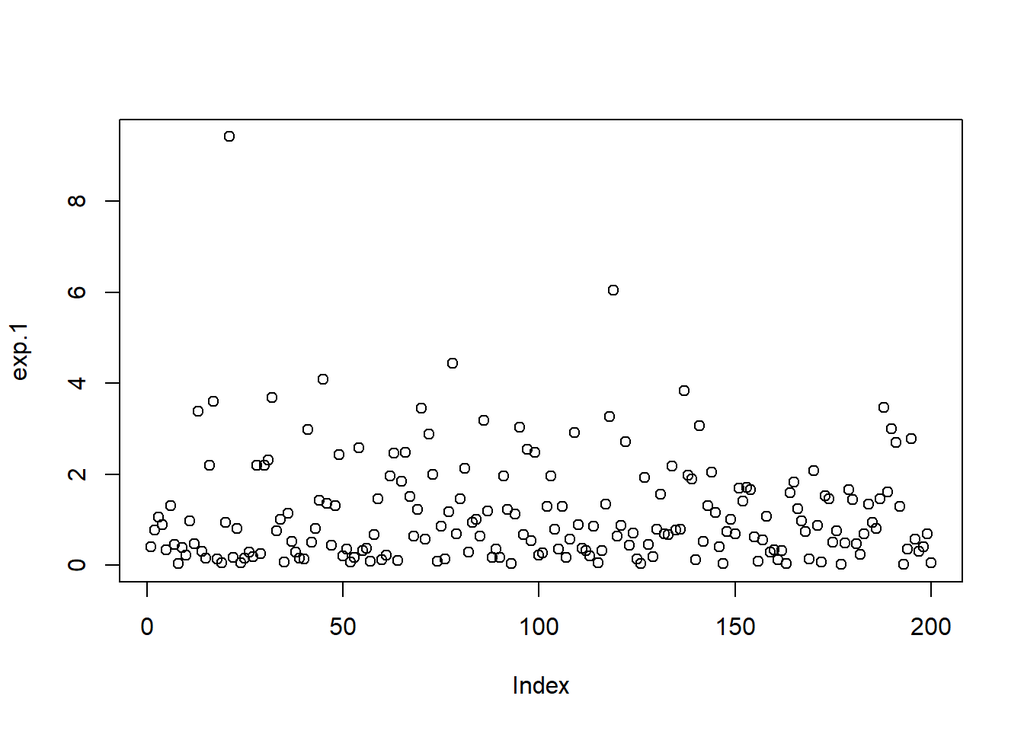

5. Используйте функцию plot() с любыми двумя полученными ранее векторами, чтобы получить диаграмму рассеяния (scatterplot) этих векторов относительно друг друга

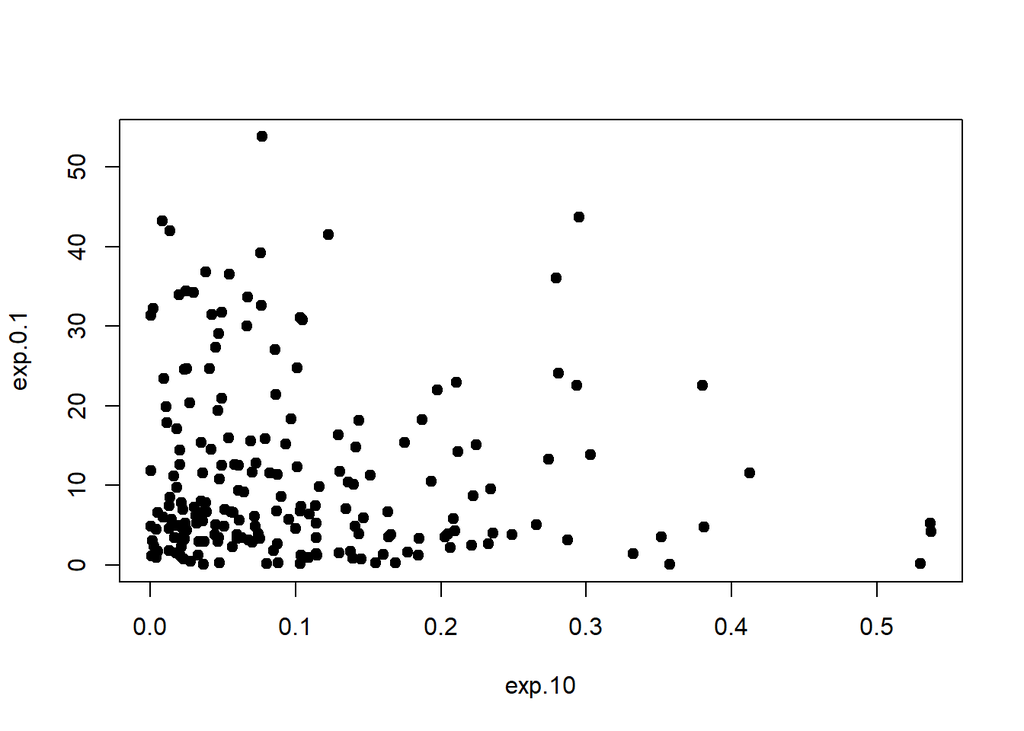

6. Теперь сравним свойства всех наших векторов. Для начала создадим вектор, содержащий средние значения каждого из 5 полученных ранее распределений в порядке их создания. Полученный вектор сохраним в переменную exp.means.

```r
exp.means <- c(mean(exp.1), mean(exp.0.1), mean(exp.0.5), mean(exp.5), mean(exp.10))
```

7. Далее необходимо создать следующие диаграммы рассеяния:
   - Вектор с пятью средними относительно каждого из пяти векторов с различными значениями λ.
   - Вектор с пятью стандартными отклонениями относительно каждого из пяти векторов с различными значениями λ.
   - Вектор с пятью средними относительно вектора с пятью стандартными отклонениями.

```r
exp.parmtrs <- c(1, 0.1, 0.5, 5, 10)
exp.sds <- c(sd(exp.1), sd(exp.0.1), sd(exp.0.5), sd(exp.5), sd(exp.10))
```

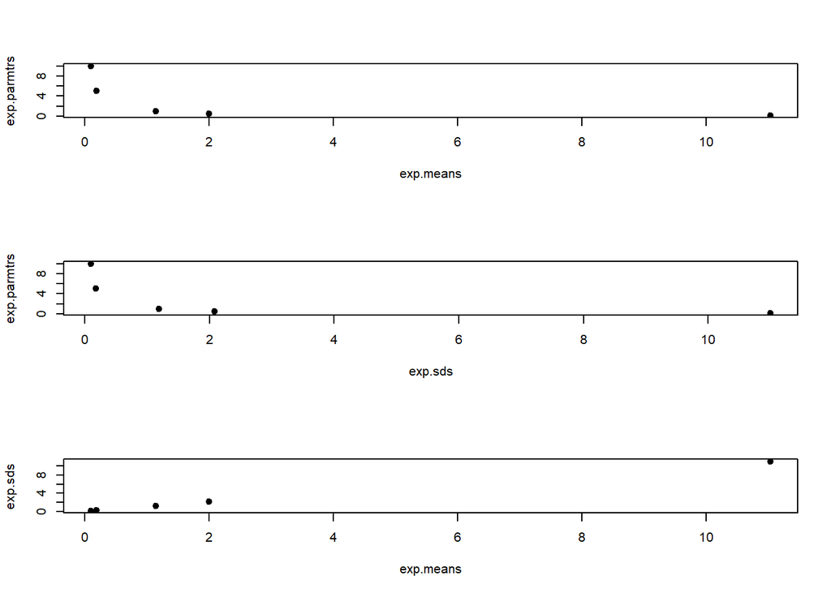

### Задание 2

1. Для демонстрации сгенерируйте 1100000 (1 млн. 100 тысяч) чисел из стандартного экспоненциального распределения и сохраните их в вектор huge.exp.1. Получите среднее и стандартное отклонение.

```r
huge.exp.1 <- rexp(1100000)
huge.exp.1.mean <- mean(huge.exp.1)
huge.exp.1.sd <- sd(huge.exp.1)
print(huge.exp.1.mean)
```

```
## [1] 0.9999511
```

```r
print(huge.exp.1.sd)
```

```
## [1] 1.001229
```

2. Получите гистограмму huge.exp.1. Она соответствует функции 1 - e:^(-x)? Должна ли?

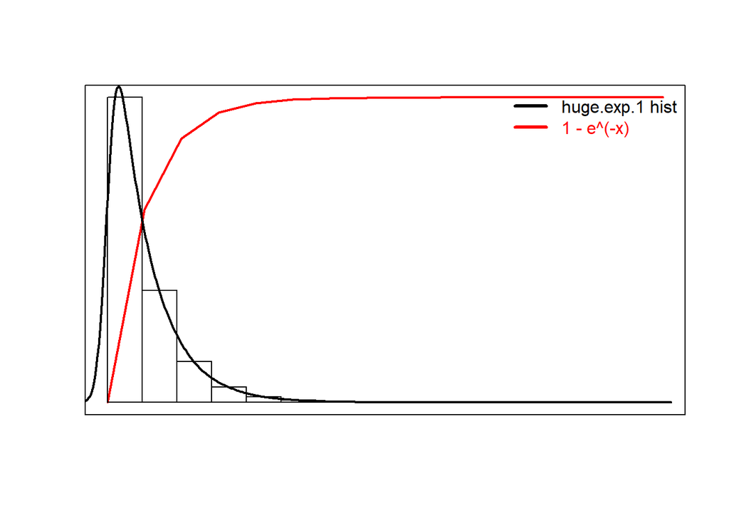

Полученный график распределения случайной величины очевидно не соответствует графику соответствующей функции распределения и не должен, т.к. в 1 случае - распределение случайной величины по экспоненциальному закону, а во втором - функция

3. Получите среднее всех чисел из huge.exp.1 строго больших 1. Для проверки выборки может потребоваться новый вектор.

```r
mean(huge.exp.1[huge.exp.1 > 1])
```

```
## [1] 2.001238
```

4. Получите матрицу huge.exp.1.mat, содержащую 1100 строк и 1000 колонок. Постройте гистограмму, использовав полученную матрицу. Что можно сказать о полученных данных?

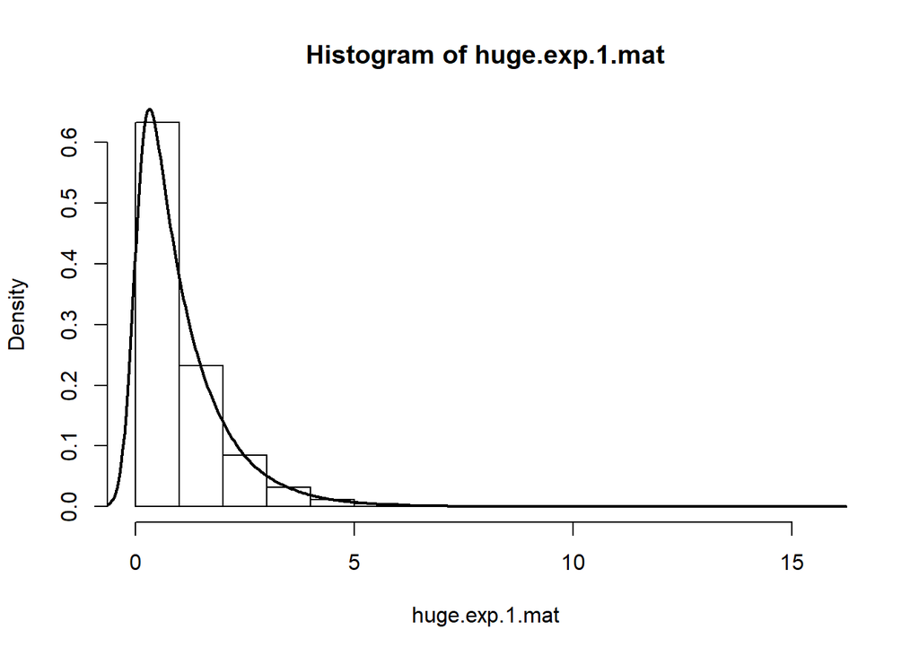

```r
huge.exp.1.mat <- matrix(huge.exp.1, 1100, 1000)
hist(huge.exp.1.mat, prob = TRUE)
lines(density(huge.exp.1.mat, adjust = 5), lwd = 2)
```

Вид гистограммы совпадает с полученной из вектора

5. Рассчитайте среднее 137-й колонки из huge.exp.1.mat.

```r
colMeans(huge.exp.1.mat)[137]
```

```
## [1] 1.002542
```

6. Найдите среднее всей 1000 колонок и сохраните их в вектор. Отобразите диаграмму средних зннчений колонок. Объясните почему форма диаграммы отличается от виденных ранее.

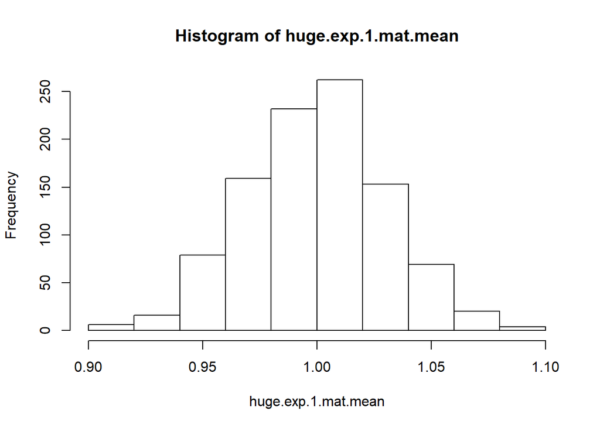

```r
huge.exp.1.mat.mean <- colMeans(huge.exp.1.mat)
hist(huge.exp.1.mat.mean)
```

Форма отличается, т.к. мы имеем дело с другими данными

7. Рассчитайте квадрат каждого значения из huge.exp.1 и найдите среднее и стандартное отклонение полученного вектора квадратов. Объясните отличие от соответствующих показателей вектора huge.exp.1.

```r
huge.exp.1.square <- huge.exp.1 ^ 2
huge.exp.1.square.mean <- mean(huge.exp.1.square)
huge.exp.1.square.sd <- sd(huge.exp.1.square)
print(huge.exp.1.square.mean)
```

```
## [1] 2.002361
```

```r
print(huge.exp.1.square.sd)
```

```
## [1] 4.50181
```

Зная как вычисляется среднее ($\frac{\sum x}{n}$) и стандартное отклонение ($\sqrt\frac{\sum [x - avg(x)]^2}{n-1}$) можно спрогнозировать как они могут измениться.

С увеличением значения *x* (вектора) увеличится значение среднего и стандартного отклонения, т.к. они находятся в числителе дроби

Уменьшение *x* приведет к обратным результатам. Предположительно, рассмотренные показатели у вектора квадратов будут больше

```r
huge.exp.1.square.mean - huge.exp.1.mean
```

```
## [1] 1.00241
```

```r
huge.exp.1.square.sd - huge.exp.1.sd
```

```
## [1] 3.500581
```

# Заключение

В ходе выполнения данной работы были изучены и закреплены на практике принципы манипулирования объектами данных, использование встроенных функций, построение простейших графиков, а также простейшие статистические концепции.